# Statistical Analysis of eDNA Results

We will firstly load the qiime2R library to load the data output from Qiime2. We will use the betapart library for diversity analyses, and ggfortify for plotting.

```r
library(qiime2R)
library(ggplot2)
library(betapart)
library(ggfortify)
```

```r
# Note: we will suppress warnings for publication
defaultW <- getOption("warn")
options(warn = -1)
```

## Loading Files

We load our Qiime2 results using read_qza.

```r
data = read_qza('/nesi/project/nesi02659/obss_2020/resources/day5/other_resources/stats/fish_freq_table.qza')
```

```r
otus = read_qza('/nesi/project/nesi02659/obss_2020/resources/day5/other_resources/stats/zotus.qza')
```

Let’s see what information we get about the respective OTUs:

```r
print(otus$type)
print(otus$format)
class(otus)
```

```
[1] "FeatureData[Sequence]"
[1] "DNASequencesDirectoryFormat"
```

'list'

```r
otus$data
```

```
DNAStringSet object of length 34:
     width seq                                              names
 [1]   202 TTTAGAACAGACCATGTCAGCTA...GGCAAAGCCGATCAACGGACCG Zotu1
 [2]   205 ACTAAGGCATATTGTGTCAAATA...GGCAAAGCCGATTAACGAACCA Zotu2
 [3]   203 ACCAAAACAGCTCCCGTTAAAAA...GGCATAGCCGATCAACGAACCG Zotu3
 [4]   203 ACAAGGCAGCCCCACGTTAAAAA...GGCAGCGCCGATCAGCGAACCA Zotu4
 [5]   205 ACTAAGACAGATCACGTCAAACA...GGCAACGCCGATCAGCGGACCG Zotu5
 ...   ... ...
[30]   202 TTTAGAACAGACCATGTCAGCTA...GGCAGCGCCGATCAGCGAACCA Zotu30
[31]   189 ACTAAAGCAGCCCCTCTTGCCCC...AGCAAAGCTGATCAACGGACCC Zotu31
[32]   210 ACTTAAGTTACTATCTTATTTAT...CTATCCCCTGATCAATGAACCA Zotu32
[33]   203 GTAAGAACAGCCCAAGTCAAAGC...GGCAACGCCGATCAACGGACCA Zotu33
[34]   201 AACGAGCAGACCATTATCCCTAC...GGCATAGCCGATCAACGAACCG Zotu34
```

We investigate our data structure, and extract the read count table that we are interested in.

```r
print(data$type)
print(data$format)
class(data)
```

```
[1] "FeatureTable[Frequency]"
[1] "BIOMV210DirFmt"
```

'list'

```r
dataf = data$data
print(dataf)
```

```
         R1   R2   R3   R4   R5   R6   M2   M3   M4   M5   M6
Zotu5  2024    0 3282 1551    0  751    0    0    0    0    0
Zotu1  3207    0    0 1029 1254  581 1854 8941 2036 3431  785
Zotu4   845 3981 1967 2007 4954 3336    0    0    0    0    0
Zotu6  1308  455    0 1642 2197  626    0    0    0    0    0
Zotu2   713 3590    0 2905  176 1954 2745 2843 4204 3765 3422
Zotu11 1920    0    0    0   84  115    0    0    0    0    0
Zotu18 1048    0    0    0    0   21    0    0    0    0    0
Zotu32   19    0    3    0    0    0    0    0    0    0    0
Zotu30    4    0    0    7   21    3    0    0    0    0    0
Zotu27    2    0    1    0   68    2    0    0    0    0    0
Zotu33    1    0    7    3    5    1    0    0    0    0    0
Zotu14    0 1594    0    0    0    0    0    0    0    0    0
Zotu7     0  485 1820    0    0    0  438  408  359  999 1830
Zotu21    0   37    0  729    0    0    0    0    0    0    0
Zotu15    0    0 1037    0   25    0    0    0    0    0    0
Zotu3     0    0    0  573    0    0 2836    0 4428  987 1884
Zotu19    0    0    0  616  198    0    0    0    0    0    0
Zotu17    0    0    0 1060    0    0    0    0    0    0    0
Zotu20    0    0    0    0  766    0    0    0    0    0    0
Zotu23    0    0    0    0  210    0    0  108    0    0    0
Zotu22    0    0    0    0  653    0    0    0    0    0    0
Zotu28    0    0    0    0   43    0    0    9    0    0    0
Zotu25    0    0    0    0  100   26    0    0    0    0    0
Zotu16    0    0    0    0    0  934    0    0    0    0    0
Zotu29    0    0    0    0    0   37    0    0    0    0    0
Zotu10    0    0    0    0    0    0 2243    0    0 1030    0
Zotu34    0    0    0    0    0    0    5    0    0    8    0
Zotu9     0    0    0    0    0    0    0 3649    0    0    0
Zotu8     0    0    0    0    0    0    0 4236    0    0    0
Zotu12    0    0    0    0    0    0    0    0    0 1464    0
Zotu13    0    0    0    0    0    0    0    0    0    0 1064
Zotu24    0    0    0    0    0    0    0    0    0    0  184
Zotu26    0    0    0    0    0    0    0    0    0    0  103
Zotu31    0    0    0    0    0    0    0    0    0    0   18
```

```r
class(dataf)
```

1. 'matrix'

2. 'array'

We now load a pre-prepared file that maps the OTUs in our frequency table to the respective taxonomies; we will then collapse OTUs that are assigned to the same species.

```r
# Currently our table only has OTUs as rownames:
rownames(dataf)
```

1. 'Zotu5'

2. 'Zotu1'

3. 'Zotu4'

4. 'Zotu6'

5. 'Zotu2'

6. 'Zotu11'

7. 'Zotu18'

8. 'Zotu32'

9. 'Zotu30'

10. 'Zotu27'

11. 'Zotu33'

12. 'Zotu14'

13. 'Zotu7'

14. 'Zotu21'

15. 'Zotu15'

16. 'Zotu3'

17. 'Zotu19'

18. 'Zotu17'

19. 'Zotu20'

20. 'Zotu23'

21. 'Zotu22'

22. 'Zotu28'

23. 'Zotu25'

24. 'Zotu16'

25. 'Zotu29'

26. 'Zotu10'

27. 'Zotu34'

28. 'Zotu9'

29. 'Zotu8'

30. 'Zotu12'

31. 'Zotu13'

32. 'Zotu24'

33. 'Zotu26'

34. 'Zotu31'

We want to substitute those with actual taxonomies!

We can load the taxonomy output delivered by Qiime2:

```r
annot = read.table('/nesi/project/uoo02328/eDNA2020/fishtest1/fish_OTUs_NB_taxonomy.tsv', sep='\t', header=TRUE, row.names=1)
```

Look at an example taxonomy annotation:

```r
annot$Taxon[1]
```

'k__Eukaryota_2759;p__Chordata_7711;c__Actinopteri_186623;o__Mugiliformes_41872;f__Mugilidae_8189;g__Aldrichetta_443747;s__Aldrichetta forsteri_443748'

Process the annotation (one example) to only get the genus level annotation:

```r
strsplit(annot$Taxon[1], ";g__")
class(strsplit(annot$Taxon[1], ";g__"))
unlist(strsplit(annot$Taxon[1], ";g__"))[2]
unlist(strsplit(unlist(strsplit(annot$Taxon[1], ";g__"))[2], '_'))[1]
```

1. 1. 'k__Eukaryota_2759;p__Chordata_7711;c__Actinopteri_186623;o__Mugiliformes_41872;f__Mugilidae_8189'

   2. 'Aldrichetta_443747;s__Aldrichetta forsteri_443748'

'list'

'Aldrichetta_443747;s__Aldrichetta forsteri_443748'

'Aldrichetta'

Apply this function to all annotations with the help of a function:

```r
f = function(x) unlist(strsplit(unlist(strsplit(x, ";g__"))[2], '_'))[1]
sapply(annot$Taxon, f, USE.NAMES = FALSE)
```

1. 'Aldrichetta'

2. 'Thyrsites'

3. 'Forsterygion'

4. 'Bovichtus'

5. 'Notolabrus'

6. 'Notothenia'

7. 'Forsterygion'

8. 'Sprattus'

9. NA

10. 'Hyporhamphus'

11. 'Retropinna'

12. 'Seriolella'

13. 'Lotella'

14. 'Hygophum'

15. 'Salmo'

16. 'Forsterygion'

17. 'Forsterygion'

18. 'Enneanectes'

19. 'Lepidopus'

20. 'Sprattus'

21. 'Forsterygion'

22. 'Odax'

23. 'Pseudophycis'

24. 'Forsterygion'

25. NA

26. NA

27. NA

28. 'Pseudophycis'

29. 'Sprattus'

30. 'Aldrichetta'

31. NA

32. 'Dipturus'

33. NA

34. 'Forsterygion'

Why do we observe NAs?

```r
# Subsitute OTU row names with genus names
rownames(dataf) = sapply(annot$Taxon, f, USE.NAMES = FALSE)
```

```r
# Delete NAs:
dataf = dataf[!rownames(dataf) %in% NA, ]
```

```r
# Aggregate reads per genus:
dataf = rowsum(dataf, row.names(dataf))
```

```r
dataf_bin = dataf
dataf_bin[dataf==1] = 0
dataf_bin[dataf>0] = 1
```

or “rarefy” the data:

```r
# look at number of reads per samples
colSums(dataf)
min(colSums(dataf))
min_reads = min(colSums(dataf))
```

**R1**

11087

**R2**

10142

**R3**

8117

**R4**

12115

**R5**

10733

**R6**

8347

**M2**

7873

**M3**

20194

**M4**

11027

**M5**

10646

**M6**

8123

7873

```r
# create rarefied table
dataf_rar = dataf
for (i in 1:dim(dataf)[2]){
  dataf_rar[,i] = rmultinom(n = 1, size = min_reads, prob = dataf[,i])
}
```

How would you calculate the alpha diversity of these samples?

```r
colSums(dataf_bin)
```

**R1**

9

**R2**

6

**R3**

7

**R4**

8

**R5**

12

**R6**

9

**M2**

4

**M3**

6

**M4**

4

**M5**

5

**M6**

5

```r
# or
sum(dataf_rar[,1] != 0)
```

9

We will now apply some standard biodiversity calculations using the betapart package; what do these results mean?

```r
betar = beta.multi(dataf_bin, index.family = "jaccard")
print(betar$beta.JAC)
```

```
[1] 0.9239001
```

We should probably not do this like that - why?

```r
dataf_bin[,1:11]
```

A matrix: 18 × 11 of type dbl

|  | R1 | R2 | R3 | R4 | R5 | R6 | M2 | M3 | M4 | M5 | M6 |
| --- | --- | --- | --- | --- | --- | --- | --- | --- | --- | --- | --- |
| Aldrichetta | 1 | 0 | 1 | 1 | 0 | 1 | 0 | 0 | 0 | 1 | 0 |
| Bovichtus | 1 | 1 | 0 | 1 | 1 | 1 | 0 | 0 | 0 | 0 | 0 |
| Dipturus | 0 | 0 | 0 | 0 | 0 | 0 | 0 | 0 | 0 | 0 | 1 |
| Enneanectes | 0 | 0 | 0 | 1 | 0 | 0 | 0 | 0 | 0 | 0 | 0 |
| Forsterygion | 1 | 1 | 1 | 1 | 1 | 1 | 1 | 0 | 1 | 1 | 1 |
| Hygophum | 0 | 1 | 0 | 1 | 0 | 0 | 0 | 0 | 0 | 0 | 0 |
| Hyporhamphus | 1 | 0 | 1 | 0 | 1 | 1 | 0 | 0 | 0 | 0 | 0 |
| Lepidopus | 0 | 0 | 0 | 0 | 1 | 0 | 0 | 0 | 0 | 0 | 0 |
| Lotella | 0 | 1 | 1 | 0 | 0 | 0 | 1 | 1 | 1 | 1 | 1 |
| Notolabrus | 1 | 1 | 0 | 1 | 1 | 1 | 1 | 1 | 1 | 1 | 1 |
| Notothenia | 1 | 0 | 0 | 0 | 1 | 1 | 0 | 0 | 0 | 0 | 0 |
| Odax | 0 | 0 | 0 | 0 | 1 | 0 | 0 | 1 | 0 | 0 | 0 |
| Pseudophycis | 0 | 0 | 0 | 0 | 1 | 1 | 0 | 1 | 0 | 0 | 0 |
| Retropinna | 1 | 0 | 1 | 1 | 1 | 1 | 0 | 0 | 0 | 0 | 0 |
| Salmo | 0 | 0 | 1 | 0 | 1 | 0 | 0 | 0 | 0 | 0 | 0 |
| Seriolella | 0 | 1 | 0 | 0 | 0 | 0 | 0 | 0 | 0 | 0 | 0 |
| Sprattus | 1 | 0 | 1 | 0 | 1 | 0 | 0 | 1 | 0 | 0 | 0 |
| Thyrsites | 1 | 0 | 0 | 1 | 1 | 1 | 1 | 1 | 1 | 1 | 1 |

```r
rowSums(dataf_bin[,1:6])
rowSums(dataf_bin[,7:11])
```

**Aldrichetta**

4

**Bovichtus**

5

**Dipturus**

0

**Enneanectes**

1

**Forsterygion**

6

**Hygophum**

2

**Hyporhamphus**

4

**Lepidopus**

1

**Lotella**

2

**Notolabrus**

5

**Notothenia**

3

**Odax**

1

**Pseudophycis**

2

**Retropinna**

5

**Salmo**

2

**Seriolella**

1

**Sprattus**

3

**Thyrsites**

4

**Aldrichetta**

1

**Bovichtus**

0

**Dipturus**

1

**Enneanectes**

0

**Forsterygion**

4

**Hygophum**

0

**Hyporhamphus**

0

**Lepidopus**

0

**Lotella**

5

**Notolabrus**

5

**Notothenia**

0

**Odax**

1

**Pseudophycis**

1

**Retropinna**

0

**Salmo**

0

**Seriolella**

0

**Sprattus**

1

**Thyrsites**

5

```r
dataf_bin_sample = matrix(c(rowSums(dataf_bin[,1:6]), rowSums(dataf_bin[,7:11])), ncol=2, dimnames=list(rownames(dataf_bin), c('R','M')))

dataf_bin_sample[dataf_bin_sample>0] = 1
```

Now we can run beta.multi again:

```r
betar_sample = beta.multi(dataf_bin_sample, index.family = "jaccard")
print(betar_sample$beta.JAC)
```

```
[1] 0.8032787
```

We can compare the abundance of the taxa between the sample types:

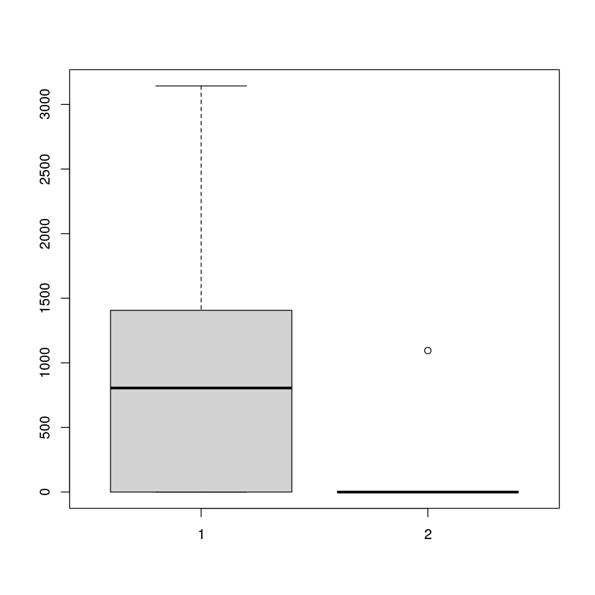

```r
boxplot(dataf_rar['Aldrichetta',1:6], dataf_rar['Aldrichetta',7:11])
```

Here is a boxplot with more information:

[figure not shown]

```r
genus = 'Aldrichetta'

boxplot(dataf_rar[genus,1:6], dataf_rar[genus,7:11], notch = TRUE,
  ylab = 'DNA read count', xlab = genus, names = c('M', 'R'))
```

We will now plot a PCA to visualise the relationship between the samples; for that we will firstly have to transpose the data so that the samples are in the rows:

```r
dataf_rar_tr = t(dataf_rar)

dataf_rar_sc = scale(dataf_rar_tr)

pca <- prcomp(dataf_rar_sc, scale. = TRUE)
```

Now we make a simple plot:

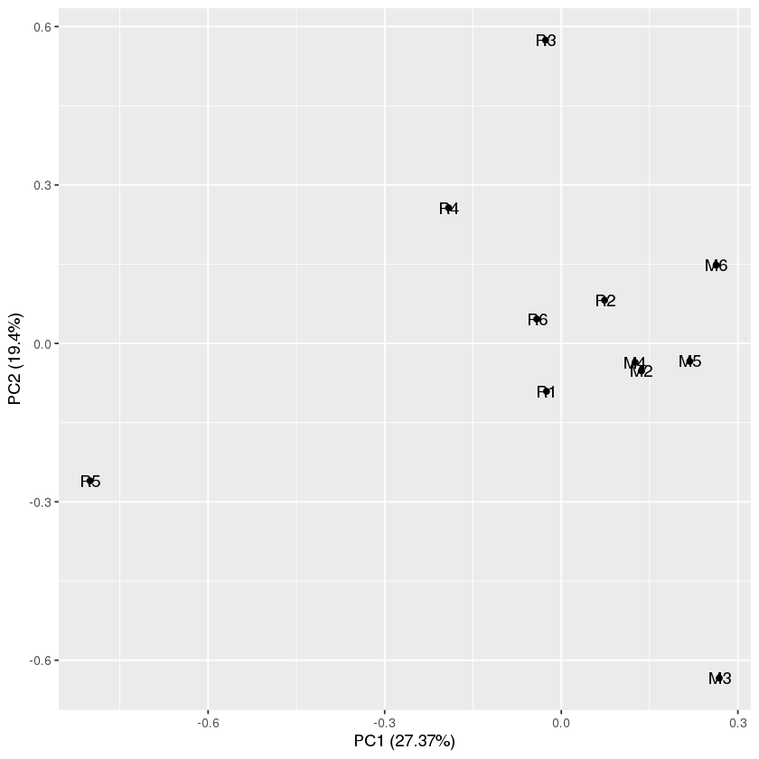

```r
autoplot(pca, label = TRUE)
```

We can modify the plot to make labels bigger:

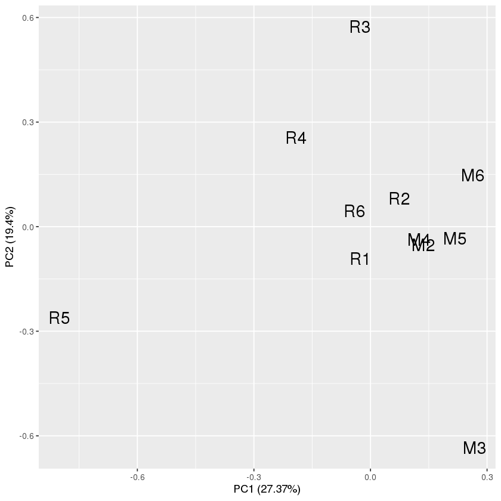

```r
autoplot(pca, label = TRUE, shape = FALSE, label.size = 6)
```

We can add colour:

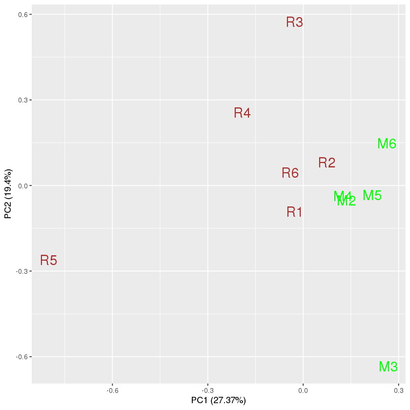

```r
autoplot(pca, label = TRUE, shape = FALSE, label.size = 6, colour = c(rep('brown',6), rep('green',5)))
```

Using the *loadings* parameter draws eigenvectors on the plot:

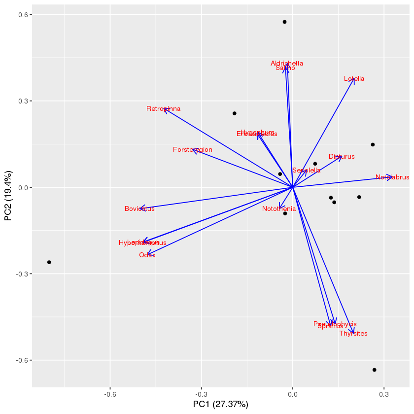

```r
autoplot(pca, loadings = TRUE, loadings.colour = 'blue', loadings.label = TRUE, loadings.label.size = 3)
```